# NemaScan Report for telomere_length

07 October, 2021

## Usage

- This R Markdown file imports data tables within Analysis_Results-Date folder and will knit without any modification.
- ggsave code is kept for users to make customized plots.

## Strain Issues

All strain names were converted to the corresponding isotype name, which can be looked up here: https://elegansvariation.org/strains/isotype_list. If you submitted replicate data, replicates for a given isotype were averaged to one mean value.

```
## [1] "No strain issues to report"
```

## Manhattan plot

#### Every dot is a SNV marker.

#### SNVs are colored red if they pass the genome-wide corrected significance threshold:

- - If Bonferroni-corrected significance (BF) threshold were used: the horizontal solid line corresponds to BF threshold, and the horizontal dash line corresponds to EIGEN threshold (see below). If user supplied threshold exists, it will replace the BF threshold.
  - If Eigen-decomposition significance threshold were used, the horizontal solid line overlaps with the dash line and corresponds to the EIGEN threshold, which corrects for the number of independent markers in your data set.

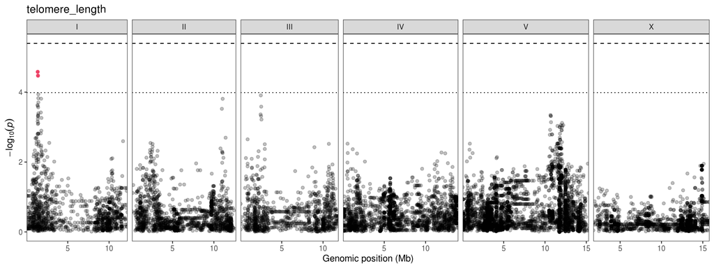

[output not shown]

## Linkage disequilibrium (LD) between QTL

```
## [1] "Not enough QTL regions to calculate linkage"
```

## Divergent region, haplotype, and fine mapping for each significant QTL region

Only for regions less than 5 Mb in size

```
## [1] "No significant QTL regions to plot"
```

## Please kindly cite the following publications

- Lee D, Zdraljevic S, Stevens L, Wang Y, Tanny RE, Crombie TA, Cook DE, Webster AK, Chirakar R, Baugh LR, Sterken M, Braendle C, Felix M-A, Rockman MV, and Andersen EC (2020) Balancing selection maintains ancient genetic diversity in C. elegans. Nature Ecology and Evolution, 2021 Apr 5; DOI: 10.1038/s41559-021-01435-x.
- Zdraljevic S, Fox BW, Strand C, Panda O, Tenjo-Castano FJ, Brady SC, Crombie TA, Doench JG, Schroeder FC, and Andersen EC (2019) Natural variation in arsenic toxicity is explained by differences in branched chain amino acid catabolism eLife, Apr 8;8: e40260.
- Cook DE, Zdraljevic S, Roberts JP, Andersen EC (2016) CeNDR, the Caenorhabditis elegans Natural Diversity Resource. Nucleic Acids Research, Jan 4; 45(D1):D650-D657.